# LSTM

```python
import pandas as pd
import tensorflow as tf
import numpy as np
import random
import matplotlib.pyplot as plt
from IPython.display import Image
import os
os.chdir('C:\\Users\\billyhsu\\Desktop')
```

# LSTM structure

[figure not shown]

# LSTM cell

[figure not shown]

```python
x1 = pd.Series(range(0,250))
x2 = pd.Series(range(1,260))
x3 = pd.Series(range(2,270))
x4 = pd.Series(range(3,280))
x5 = pd.Series(range(4,290))
y1  = pd.Series(range(10,500))
y2  = pd.Series(range(20,4050))
y3  = pd.Series(range(30,5050))
```

```python
data = pd.DataFrame({'x1':x1,'x2':x2,'x3':x3,'x4':x4,'x5':x5,'y1':y1})
data = pd.DataFrame({'x1':x1,'x2':x2,'x3':x3,'x4':x4,'x5':x5,'y1':y1}).dropna()

# data = pd.DataFrame({'x1':x1,'x2':x2,'x3':x3,'x4':x4,'x5':x5,'x6':x6,'x7':x7,'x8':x8,'x9':x9,'y1':y1,'y2':y2,'y3':y3})
```

# Batch資料製作

```python
def TS_data_Batch(batch_size,n_inputs,n_steps,data_x,data_y, y_len):
    LSTM_x_temp = []
    LSTM_y_temp = []

    for i in range(0,len(data_x)-n_steps+1):
        LSTM_x_temp.append(data_x[i:i+n_steps].values.reshape([-1,n_steps,n_inputs]))
        LSTM_y_temp.append(data_y[i:i+n_steps].values.reshape([-1,n_steps,n_outputs]))

    if batch_size >1 :
        LSTM_x = []
        LSTM_y = []
        for i in range(0,len(LSTM_x_temp),batch_size):
            LSTM_x.append(np.array(LSTM_x_temp[i:i+batch_size]).reshape([-1,n_steps,n_inputs]).astype(np.float32))
            LSTM_y.append(np.array(LSTM_y_temp[i:i+batch_size]).reshape([-1,n_steps,n_outputs]).astype(np.float32))

    if batch_size ==1:

        total_len = len(LSTM_x_temp)
        split_len = y_len

        train_x = LSTM_x_temp[ 0:total_len- split_len]
        train_y = LSTM_y_temp[ 0:total_len- split_len]
        test_x  = LSTM_x_temp[ total_len- split_len :total_len ]
        test_y  = LSTM_y_temp[ total_len- split_len : total_len]

        return train_x ,train_y, test_x, test_y

    elif batch_size >1 :

        total_len = len(LSTM_x)
        split_len = y_len
        train_x = LSTM_x[ 0:total_len - split_len]
        train_y = LSTM_y[ 0:total_len - split_len]
        test_x  = LSTM_x[ total_len- split_len:total_len ]
        test_y  = LSTM_y[ total_len- split_len: total_len]

        return train_x ,train_y, test_x, test_y
```

# Hyperparameters

- epochs: this correspond to the number of iterations we are going to run the data set through our model.
- n_steps: It is how long in time each of your samples are.
- n_outputs: this corresponds to the number of outputs.
- n_hidden: This corresponds to the size of the hidden state of the LSTM (both c and h).
- n_inputs: this represents the number of features in the dataset.
- batch_size: This refers to the size of each batch of data you are going to feed into the model. Back-propagation will be done once per batch.
- learning_rate

```python
batch_size =1    # 一次訓練一筆資料
n_steps = 4         # 三列 (ROW) 資料當成一筆
n_inputs = 5       # 三個特徵進行訓練
layers_n_hidden = [300,200,50]       # 三個神經元
activations  = [tf.nn.relu, tf.nn.relu, tf.nn.relu]
n_outputs = 1       # 產出三個輸出值 (對應 n_steps)
trainEpoch= 1000 #訓練一萬次
learning_rate= 0.001
```

```python
data_x = data.drop('y1',axis= 1)
data_y = data['y1']
```

```python
train_x, train_y, test_x, test_y = TS_data_Batch(batch_size,n_inputs,n_steps,data_x,data_y,y_len=20)
```

# LSTM Model Building

```python
x = tf.placeholder(tf.float32, [None, n_steps, n_inputs])

#y = tf.placeholder(tf.float32, [None, n_step ,n_outputs])
y = tf.placeholder(tf.float32, [None,n_steps,n_outputs])

weights = {'in': tf.Variable(tf.random_normal([n_inputs,layers_n_hidden[0]])),
          'out': tf.Variable(tf.random_normal([layers_n_hidden[-1],n_outputs]))}
biases = {'in': tf.Variable(tf.random_normal([layers_n_hidden[0],])),
          'out': tf.Variable(tf.random_normal([n_outputs,]))}
```

# LSTM Model Building- 1

- "outputs" variable contains all the outputs of the LSTM layer for each time step.
- "final_state" contains the values of the last state of both the hidden states (h and c).
- "results" reshape the outputs to 2D for matrix mutiply weights['out'] and plus biases['outs']
- If we wants the the last output of the LSTM layer using ‘outputs[-1]’

```python
def Multi_LSTM_Model(X,weights,biases,num_layers):
    #為了矩陣相乘先轉 2D
    x = tf.reshape(X,[-1,n_inputs])
    x_in = tf.matmul(x, weights['in'])+ biases['in']
    # 矩陣乘完後轉回 3D
    x_in = tf.reshape(x_in,[-1,n_steps,layers_n_hidden[0]])
    # 製作 LSTM 最基本的 Cell

    cell = [tf.contrib.rnn.BasicLSTMCell(n_hidden,forget_bias=1.0,activation = activation)
            for n_hidden, activation in zip(layers_n_hidden ,activations) ]

    # *num_layers  疊 num_layers 的層數
    Multi_cell = tf.nn.rnn_cell.MultiRNNCell(cell, state_is_tuple=True)
    # 設定 LSTM Cell 初始狀態為 0
    init_state = Multi_cell.zero_state(batch_size = tf.shape(X)[0],dtype=tf.float32)
    # 輸出 LSTM 的運算
    outputs, final_state = tf.nn.dynamic_rnn(Multi_cell, x_in, initial_state=init_state, time_major=False)
#     outputs = tf.unstack(tf.transpose(outputs, [1,0,2]))
    results = tf.matmul(outputs, weights['out']) + biases['out']
    return results
```

# LSTM Model Building- 2

```python
pred = Multi_LSTM_Model(x, weights, biases,len(layers_n_hidden))

# ####
loss_function = tf.reduce_mean(tf.sqrt(tf.square(tf.reshape(pred,[-1])-tf.reshape(y, [-1]))))
Accuracy = tf.abs(1-tf.reduce_mean((tf.abs(tf.reshape(pred,[-1])-tf.reshape(y, [-1])) ) /tf.reshape(y, [-1])))
result = tf.abs(tf.reshape(pred,[-1])-tf.reshape(y, [-1]))
optimizer = tf.train.AdamOptimizer(learning_rate=learning_rate)
trainer = optimizer.minimize(loss_function)
```

[output not shown]

# LSTM Model Building- 3

- optimizer: Minimize tha AdamOptimizer.

# LSTM Model Building- Learning rate decay

## exponential_decay

[figure not shown]

### learning_rate 傳入初始 lr 值， global_step 用於逐步計算衰減指數， decay_steps 用於決定衰減週期， decay_rate 是每次衰減的倍率， staircase 若為 False 則是標準的指數型衰減， True 時則是階梯式的衰減方法，目的是為了在一段時間內（往往是相同的 **epoch** 內）保持相同的 learning rate。

### formula:

### *decayed learning rate*$ = $ *learning rate* $ \times$ *decay rate* $^{\frac{\mbox{global step}}{\mbox{decay steps}}}$

exponential_decay：

### code:

```
exponential_decay(learning_rate, global_step, decay_steps, decay_rate, staircase=False, name=None)
```

```python
### set learing rate decay ###

# start_lr = 0.1 # 起始 learning rate
# step_rate = 5  # 幾步之後 learning rate 下降 (以迴圈計算)
# decay = 0.95  # 下降率

# global_step = tf.Variable(0, trainable=False)  # 製作計算步數的變數
# increment_global_step = tf.assign(global_step, global_step + 1) # 計算跑幾圈迴圈了
# learning_rate = tf.train.exponential_decay(start_lr, global_step,
#                                            step_rate, decay, staircase=True) # 學習率下降函數 staircase = True 階梯般陡降
#                                                                              # 學習率下降函數 staircase = False 緩降
# optimizer = tf.train.AdamOptimizer(learning_rate=learning_rate, epsilon=0.01)
# trainer = optimizer.minimize(loss_function,global_step=global_step)  #global_step = global_step 一定要打。
```

```python
sess = tf.Session()
sess.run(tf.global_variables_initializer())
epoch_list, loss_list= [],[]
```

```
Train Epoch: 00 Loss=52.9600 Overall_Accuracy= 0.7787
Train Epoch: 10 Loss=1.7953 Overall_Accuracy= 0.9922
Train Epoch: 20 Loss=1.7468 Overall_Accuracy= 0.9912
Train Epoch: 30 Loss=0.8696 Overall_Accuracy= 0.9969
Train Epoch: 40 Loss=0.8621 Overall_Accuracy= 0.9957
Train Epoch: 50 Loss=0.5482 Overall_Accuracy= 0.9975
Train Epoch: 60 Loss=1.5256 Overall_Accuracy= 0.9942
Train Epoch: 70 Loss=14.5284 Overall_Accuracy= 0.9377
Train Epoch: 80 Loss=1.1695 Overall_Accuracy= 0.9940
Train Epoch: 90 Loss=1.4421 Overall_Accuracy= 0.9935
Train Epoch: 100 Loss=3.6128 Overall_Accuracy= 0.9842
Train Epoch: 110 Loss=1.4950 Overall_Accuracy= 0.9946
Train Epoch: 120 Loss=4.6242 Overall_Accuracy= 0.9805
Train Epoch: 130 Loss=0.8821 Overall_Accuracy= 0.9952
Train Epoch: 140 Loss=1.2700 Overall_Accuracy= 0.9942
Train Epoch: 150 Loss=0.8806 Overall_Accuracy= 0.9967
Train Epoch: 160 Loss=nan Overall_Accuracy= nan
Train Epoch: 170 Loss=nan Overall_Accuracy= nan
Train Epoch: 180 Loss=nan Overall_Accuracy= nan
Train Epoch: 190 Loss=nan Overall_Accuracy= nan
Train Epoch: 200 Loss=nan Overall_Accuracy= nan
Train Epoch: 210 Loss=nan Overall_Accuracy= nan
Train Epoch: 220 Loss=nan Overall_Accuracy= nan
Train Epoch: 230 Loss=nan Overall_Accuracy= nan
Train Epoch: 240 Loss=nan Overall_Accuracy= nan
Train Epoch: 250 Loss=nan Overall_Accuracy= nan
Train Epoch: 260 Loss=nan Overall_Accuracy= nan
Train Epoch: 270 Loss=nan Overall_Accuracy= nan
Train Epoch: 280 Loss=nan Overall_Accuracy= nan
Train Epoch: 290 Loss=nan Overall_Accuracy= nan
Train Epoch: 300 Loss=nan Overall_Accuracy= nan
Train Epoch: 310 Loss=nan Overall_Accuracy= nan
Train Epoch: 320 Loss=nan Overall_Accuracy= nan
Train Epoch: 330 Loss=nan Overall_Accuracy= nan
Train Epoch: 340 Loss=nan Overall_Accuracy= nan
Train Epoch: 350 Loss=nan Overall_Accuracy= nan
Train Epoch: 360 Loss=nan Overall_Accuracy= nan
Train Epoch: 370 Loss=nan Overall_Accuracy= nan
Train Epoch: 380 Loss=nan Overall_Accuracy= nan
Train Epoch: 390 Loss=nan Overall_Accuracy= nan
```

[output cut: 45 more lines]

```
Train Epoch: 850 Loss=nan Overall_Accuracy= nan
Train Epoch: 860 Loss=nan Overall_Accuracy= nan
Train Epoch: 870 Loss=nan Overall_Accuracy= nan
Train Epoch: 880 Loss=nan Overall_Accuracy= nan
Train Epoch: 890 Loss=nan Overall_Accuracy= nan
Train Epoch: 900 Loss=nan Overall_Accuracy= nan
Train Epoch: 910 Loss=nan Overall_Accuracy= nan
Train Epoch: 920 Loss=nan Overall_Accuracy= nan
Train Epoch: 930 Loss=nan Overall_Accuracy= nan
Train Epoch: 940 Loss=nan Overall_Accuracy= nan
Train Epoch: 950 Loss=nan Overall_Accuracy= nan
Train Epoch: 960 Loss=nan Overall_Accuracy= nan
Train Epoch: 970 Loss=nan Overall_Accuracy= nan
Train Epoch: 980 Loss=nan Overall_Accuracy= nan
Train Epoch: 990 Loss=nan Overall_Accuracy= nan
```

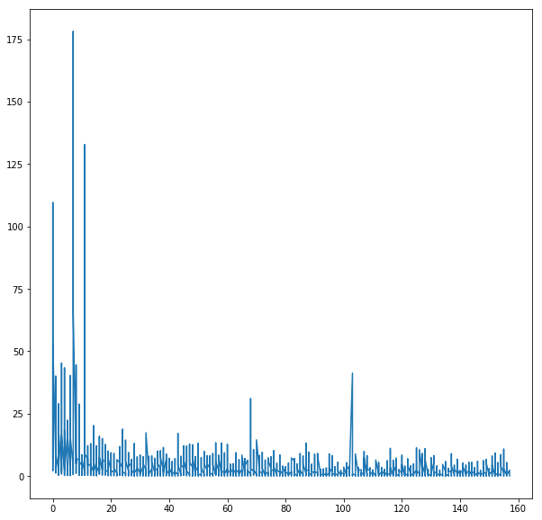

```python
for epoch in range(trainEpoch):#設定跑幾圈
    X_train,y_train,totalBatches = train_x, train_y , len(train_x)
      #for initialize the weight for each epoch.
#     sess.run(weights['in'].initializer)
#     sess.run(weights['out'].initializer)
#     sess.run(biases['in'].initializer)
#     sess.run(biases['out'].initializer)
    for i in range(totalBatches):
        batch_x, batch_y = X_train[i] , y_train[i]    #給定 batch 資料集中的第 i 筆資料

        sess.run(trainer ,feed_dict ={x : batch_x, y : batch_y})  #餵 batch 的資料給 tensorflow 的 optimizer

        loss = sess.run(loss_function, feed_dict={x: batch_x, y: batch_y}) #餵 batch 的資料給 tensorflow 的 loss_function

        epoch_list.append(epoch)
        loss_list.append(loss)
    Acc = []
    for i in range(len(test_x)):
        Acc.append(sess.run(Accuracy, feed_dict={x: test_x[i],y:test_y[i]})) # 計算 test data的預測準確度
    if epoch %  10==0 :
        print("Train Epoch:", '%02d' %(epoch),"Loss={:.4f}".format(loss) ,
              'Overall_Accuracy= {:.4f}'.format(np.mean(Acc)))#, "Accuracy=", acc)
plt.figure(figsize=(10,10))
plt.plot(epoch_list,loss_list)
plt.show()
```

# Gradient Vanish and Explode

[figure not shown]

```python
Image(filename='HOME/Epoch.png',width= 800, height =800)
```

## Gradient Vanish

- 梯度會消失的原因在於初始權重太小， 導致 loss 無法有效更新。
- RNN 會梯度消失所以改用 LSTM， 但是 LSTM 無法改變 RNN 剃度爆炸。

## Gradient Explode

- 梯度會爆炸的原因在於初始權重太大， 導致 loss 出現 NaN。

[figure not shown]

```python
Image(filename='HOME/explode.png',width= 800, height =800)
```

### Gradient Explode solutions

- Clipping
- 設定較小的 learning rate
- weight reguralization

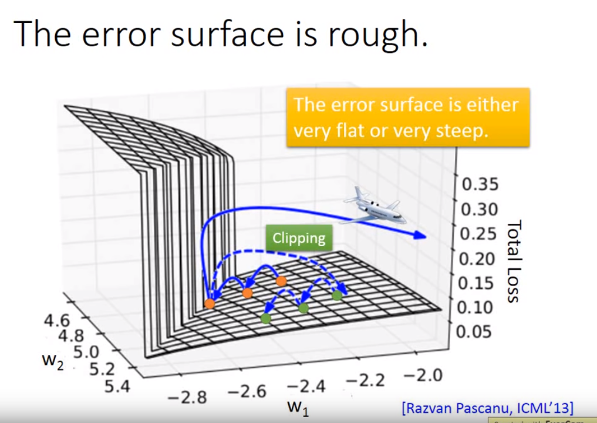

```python
Image(filename='HOME/clip.png',width= 800, height =800)
```

# Further Reading

## Data Preparation

Before we can fit an LSTM model to the dataset, we must transform the data.

The following three data transforms are performed on the dataset prior to fitting a model and making a forecast.

Transform the time series data so that it is stationary. Specifically, a lag=1 differencing to remove the increasing trend in the data. Transform the time series into a supervised learning problem. Specifically, the organization of data into input and output patterns where the observation at the previous time step is used as an input to forecast the observation at the current time timestep Transform the observations to have a specific scale. Specifically, to rescale the data to values between -1 and 1 to meet the default hyperbolic tangent activation function of the LSTM model. These transforms are inverted on forecasts to return them into their original scale before calculating and error score.

## Experimental Runs

Each experimental scenario will be run 10 times.

The reason for this is that the random initial conditions for an LSTM network can result in very different results each time a given configuration is trained.

# RELU weight matrix 的方法

## Experimental time_steps

The univariate time series is converted to a supervised learning problem before training the model. The specified number of time steps defines the number of input variables (X) used to predict the next time step (y). As such, for each time step used in the representation, that many rows must be removed from the beginning of the dataset. This is because there are no prior observations to use as time steps for the first values in the dataset.

Reference: https://machinelearningmastery.com/use-timesteps-lstm-networks-time-series-forecasting/

# LSTM Model Building- Learning rate decay

# Loss and best learning rate

[figure not shown]

## natural_exp_decay

[figure not shown]

### natural_exp_decay 和 exponential_decay 形式差不多，只不過自然指數下降的底數是自然指數型。

### formula:

### *decayed learning rate*$ = $ *learning rate* $ \times \exp{(- decay\mbox{ } rate \times \frac{ global\mbox{ } step}{ decay\mbox{ } steps})}$

### code:

```
natural_exp_decay(learning_rate, global_step, decay_steps,decay_rate,staircase=False,name=None)
```

## piecewise_constant

[figure not shown]

### 分段常數下降法類似於 exponential_decay 中的階梯式下降法，不過各階段的值是自己設定的。

### 其中， x 即為 global step ， boundaries=[step_1, step_2, …, step_n] 定義了在第幾步進行 lr 衰減， values = [val_0,val_1, val_2, …, val_n] 定義了 lr 的初始值和後續衰減時的具體取值。需要注意的是， values 應該比 boundaries 長一個維度。

### Note : 這種方法有助於使用者針對不同任務進行精細地調參數，在任意步長後下降任意數值的 learning rate。

### code:

```
piecewise_constant(x, boundaries, values, name=None)
```

## polynomial_decay

[figure not shown]

polynomial_decay 示範圖，cycle=False，其中紅色線 power=1，即線性下降；藍色線 power=0.5 ， 開根號下降；綠色線為 power=2，即二次下降

### This function applies a polynomial decay function to a provided initial `learning_rate` to reach an `end_learning_rate` in the given `decay_steps`.

[figure not shown]

polynomial_decay 示範圖，cycle=True，颜色同上。

### code:

```
polynomial_decay(learning_rate, global_step, decay_steps,
                 end_learning_rate=0.0001, power=1.0,
                 cycle=False, name=None)
```

## inverse_time_decay

[figure not shown]

inverse_time_decay 為倒數衰減，衰减公式如下所示：

### formula:

### *decayed_learning_rate* $= \frac{\mbox{learning rate}}{ \mbox{1} + \mbox{decay rate} \times \frac{\mbox{global step}}{\mbox{decay step}}}$

### code:

```
inverse_time_decay(learning_rate, global_step, decay_steps, decay_rate,
                   staircase=False, name=None)
```

## Expoential decay summary

以上幾種衰減方式相差不大，主要都是基於指數型的衰減。個人理解其問題在於一開始lr就快速下降，在復雜問題中可能會導致快速收斂於局部最小值而沒有較好地探索一定範圍內的參數空間。

## Cosine decay

[figure not shown]

cosine_decay是近一年才提出的一種lr衰減策略，基本形狀是餘弦函數。其方法是基於論文實現的：SGDR: Stochastic Gradient Descent with Warm Restarts

### formula:

```
global_step = min(global_step, decay_steps)
cosine_decay = 0.5 * (1 + cos(pi * global_step / decay_steps))
decayed = (1 — alpha) * cosine_decay + alpha
decayed_learning_rate = learning_rate * decayed
```

### code:

```
cosine_decay(learning_rate, global_step, decay_steps, alpha=0.0, name=None)
```

Reference: https://medium.com/ai反斗城/learning-model-gradient-descent中learning-rate-decay介紹-6e71af82fc9f

# How to solve gradient explode- 1

The underflow or overflow of weights is generally refers to as an instability of the network training process and is known by the name “exploding gradients” as the unstable training process causes the network to fail to train in such a way that the model is essentially useless.

# How to solve gradient explode- 2

In a given neural network, such as a Convolutional Neural Network or Multilayer Perceptron, this can happen due to a poor choice of configuration.

Some examples include:

- Poor choice of learning rate that results in large weight updates.
- Poor choice of data preparation, allowing large differences in the target variable.
- Poor choice of loss function, allowing the calculation of large error values.

# How to solve gradient explode- 3

### Exploding gradients is also a problem in recurrent neural networks such as the Long Short-Term Memory network given the accumulation of error gradients in the unrolled recurrent structure.

Exploding gradients can be avoided in general by careful configuration of the network model, such as choice of small learning rate, scaled target variables, and a standard loss function. Nevertheless, exploding gradients may still be an issue with recurrent networks with a large number of input time steps.

# Difficulty of training LSTM

One difficulty when training LSTM with the full gradient is that the derivatives sometimes become excessively large, leading to numerical problems. To prevent this, [we] clipped the derivative of the loss with respect to the network inputs to the LSTM layers (before the sigmoid and tanh functions are applied) to lie within a predefined range.

— Generating Sequences With Recurrent Neural Networks, 2013.

# Two main methods for updating the error derivative- 1

- Gradient Scaling: involves normalizing the error gradient vector such that vector norm (magnitude) equals a defined value, such as 1.0.
- Gradient Clipping: involves forcing the gradient values (element-wise) to a specific minimum or maximum value if the gradient exceeded an expected range.

Together, these methods are often simply referred to as “gradient clipping.”

# Two main methods for updating the error derivative- 2

### How to choose the value for the gradient vector norm or preferred range ?

- trail and error

The value for the gradient vector norm or preferred range can be configured by trial and error, by using common values used in the literature or by first observing common vector norms or ranges via experimentation and then choosing a sensible value.

## Reference

ML Lecture 21-1: Recurrent Neural Network (Part I)

https://www.youtube.com/watch?v=xCGidAeyS4M

ML Lecture 21-2: Recurrent Neural Network (Part II)

https://www.youtube.com/watch?v=rTqmWlnwz_0

Learning Model : Gradient Descent-learning rate decay介紹

https://medium.com/ai反斗城/learning-model-gradient-descent中learning-rate-decay介紹-6e71af82fc9f

How to Avoid Exploding Gradients With Gradient Clipping

https://machinelearningmastery.com/how-to-avoid-exploding-gradients-in-neural-networks-with-gradient-clipping/